# DM_Project_Group27

### 3.3. Graph of missing values after dropping rows and columns

It can be seen we are left with good enough data to do gender prediciton. If we didn't drop the rows and columns and fill the columsn with filling method, we might have introduced bias in our data, which is not good for features building for gender prediction model.

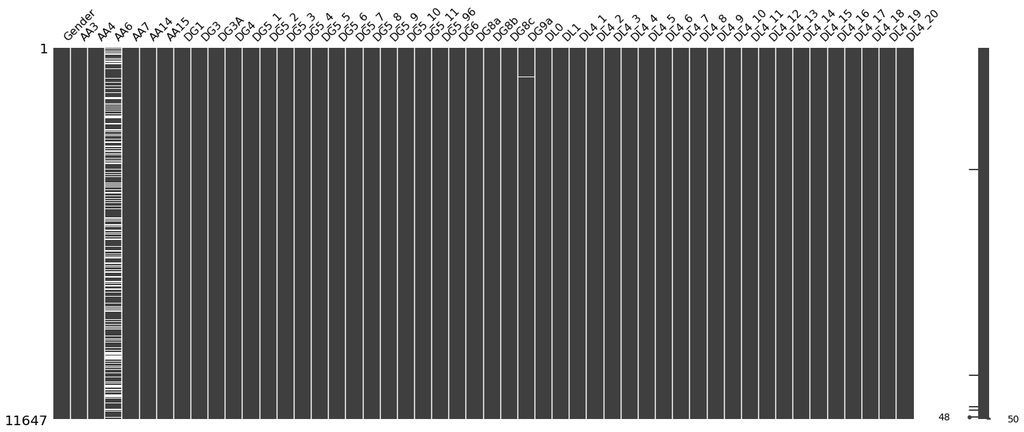

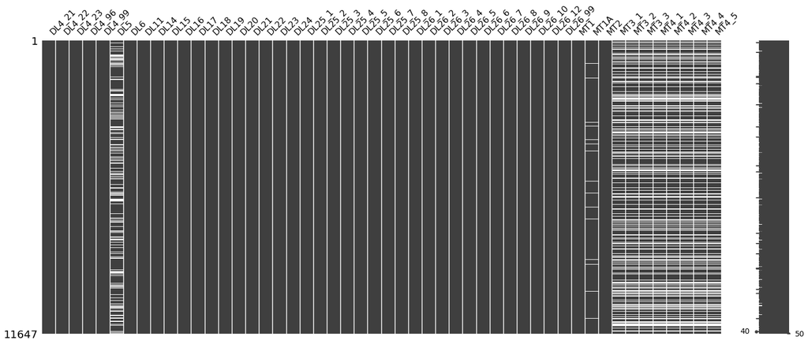

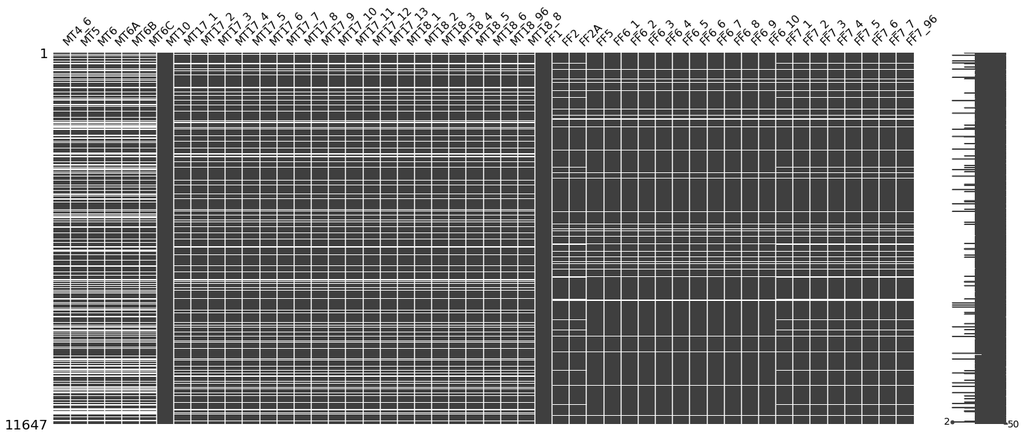

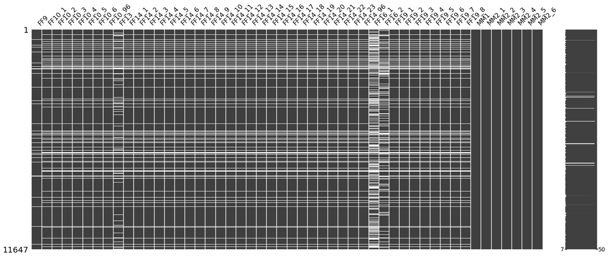

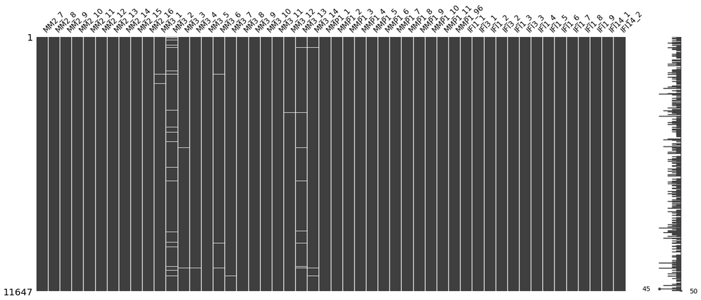

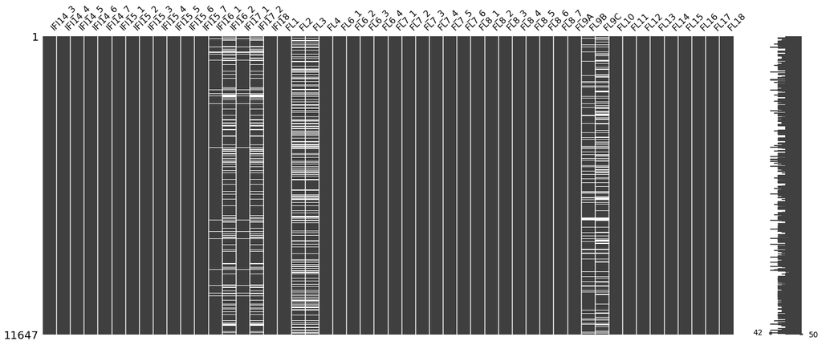

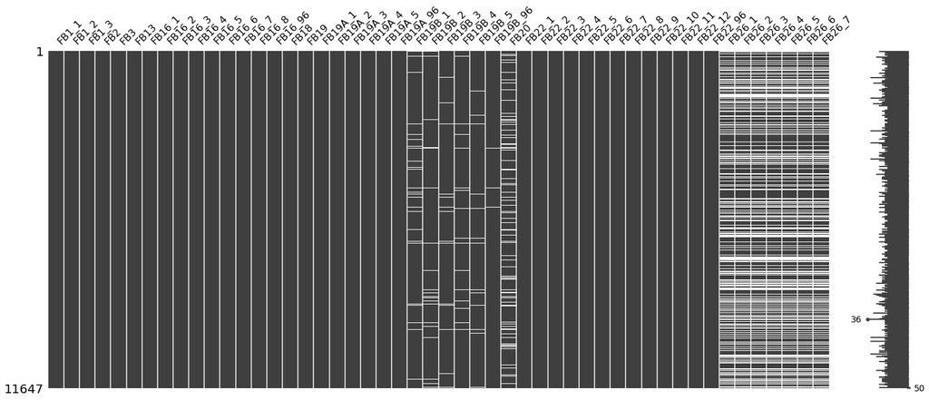

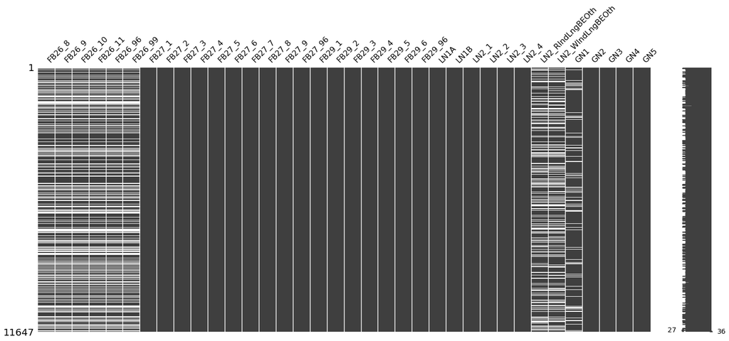

```python
cols = data_filtered.columns
cols_length = len(cols)
for index in range(0,cols_length,chunk_size):
    set = data_filtered[cols[index:index+chunk_size]]
    msno.matrix(set, inline=False)
```

```python
def drawBarChartOfTypes(data_filtered, title):
    #print(data_filtered.applymap(type))
    columns_types = data_filtered.dtypes.unique()
    columns_types_counts = data_filtered.dtypes.value_counts()
    barchart_x = []
    barchart_y = []

    for  inedex, col_type_count in  enumerate(columns_types_counts):
        barchart_x.append(str(columns_types[inedex]))
        barchart_y.append(col_type_count)
        #print(columns_types[inedex], col_type_count)

    bars = plt.bar(barchart_x, barchart_y)
    plt.title(title+" , Total Columns: "+str(remaining_columns_count))


    for bar in bars:
        yval = bar.get_height()
        plt.text(bar.get_x(), yval + .05, yval)
```

## 4. Counts of Columns Datatypes

Counts of all unique data types for columns in data

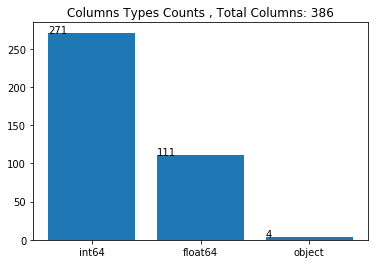

```python
drawBarChartOfTypes(data_filtered, 'Columns Types Counts')
```

## 5. Missing Columns in dictionary

Following cell prints the columns that are in our filtered data but we don't have any information about them in dictionary.

```python
#these are not ALL missing columns but those we need but not in dictionary
columns_in_dictionary = list(data_dictionaary['Column Name'])
filtered_columns = data_filtered.columns
missing_columns_in_dictionary = []

for filtered_column in filtered_columns:
    #print(filtered_column)
    if filtered_column not in columns_in_dictionary:
        missing_columns_in_dictionary.append(filtered_column)
(missing_columns_in_dictionary)
#columns_in_dictionary
```

```
['AA4',
 'AA7',
 'AA14',
 'AA15',
 'DL4_96',
 'DL4_99',
 'DL14',
 'MT3_1',
 'MT3_2',
 'MT3_3',
 'LN2_RIndLngBEOth',
 'LN2_WIndLngBEOth']
```

```python
data_filtered_corr_matrix = data_filtered.corr()
```

```python
#ax = sns.heatmap(data_filtered_corr_matrix, annot=True, cmap="YlGnBu")
```

## 6. Data Type conversion

After calcuating correlation matrix, we noticed that size of columns correlation matrix is not equal to size of columns of filtered_data. After analyzing, we found that we need to handle *object* data types to include in correlation matrix.

Even the columns has type object they still contains numeric values except two obj columns LN2_RIndLngBEOth, LN2_WIndLngBEOth, we decided to drop them, becuase these columns are location information and has nothing to do with gender. More justification in report.

In the column FB16_6 we found an garbage value 'Gujraati' at index [10619], as per dictionary this column is supposed to have only numeric values. So assuming the data might not be filled nicely for whole row we removed the row.

```python
#warning! this column included delteions, don't execute this column again and again

missing_correlation_columns = []
for filtered_column in filtered_columns:
    if filtered_column not in data_filtered_corr_matrix:
        missing_correlation_columns.append(filtered_column)

#we identified missing colums in the correlation and found that correlation matrix does not include for object types
print("Missing Columns in Correlation Matrix", missing_correlation_columns) #actually these are columsn with type object, we need to convert them to numeric
print("Object type columns",list(data_filtered.select_dtypes(['object']).columns))



#if we execute the data type conversion satement below, it throws an error, becuase two columns named 'LN2_RIndLngBEOth', 'LN2_WIndLngBEOth' are nominal, we don't have information about these columns in dictionary, so we decided to drop them from data
unknown_cols_to_drop = ['LN2_RIndLngBEOth', 'LN2_WIndLngBEOth']
for uk_col in unknown_cols_to_drop:
    if uk_col in data_filtered:
        data_filtered = data_filtered.drop([uk_col], axis=1)
    if uk_col in missing_correlation_columns:
        missing_correlation_columns.remove(uk_col)



print("Change type of", missing_correlation_columns)


#while executing the conversion statment we get following error
#'Unable to parse string "Gujarati" at position 10619', 'occurred at index FB16_6'
#after analyzing from dictionary we got to know this value not from an acceptable value domain. so we decided to remove the row

#if data_filtered.FB16_6[10619] == "Gujarati": #this can be thougt of garbage value
data_filtered.drop(data_filtered.index[10619], inplace=True)
print(data_filtered.shape)
data_filtered[missing_correlation_columns] = data_filtered[missing_correlation_columns].apply(pd.to_numeric)
```

```
Missing Columns in Correlation Matrix ['FB16_5', 'FB16_6', 'LN2_RIndLngBEOth', 'LN2_WIndLngBEOth']
Object type columns ['FB16_5', 'FB16_6', 'LN2_RIndLngBEOth', 'LN2_WIndLngBEOth']
Change type of ['FB16_5', 'FB16_6']
(11646, 384)
```

### 6.1. Post conversion counts of columns data types

Counts of all unique data types for columns in data after data type conversion

[figure not shown]

```python
drawBarChartOfTypes(data_filtered, "Columns Types Count after changing data types Obj=> Numeric")
```

### 6.2. Recomputation of Correlation Matrix

This time size of columns in correlation matrix matches with size of columns in data

```python
#recompute correlation matrix
data_filtered_corr_matrix = data_filtered.corr()
print("Columns in correlation matrix", len(data_filtered_corr_matrix), "\nColumns in data", data_filtered.shape[1])
```

```
Columns in correlation matrix 384
Columns in data 384
```

```python
def drawCorrelationChart(col_name, data, title):

    #ax = sns.heatmap(data, annot=True, cmap="YlGnBu")
    #data = list(data)
    y_axis = list(data[col_name].values)
    #x_axis = list(data.columns)
    #print(y_axis)
    plt.bar(range(0,len(y_axis)), y_axis)
    plt.title(title)
    plt.xlabel('Column Number')
    plt.ylabel('Correlation')
```

### 6.3. Columns Correlation with Gender

As per project requirement our task is to predict gender. For further data cleaning we want know the columns correlation with gender.

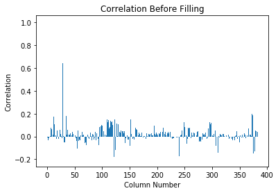

```python
drawCorrelationChart("Gender",data_filtered_corr_matrix, "Correlation Before Filling")
```

### 6.4. Correlated Columns with threshold

For now, we decided to not drop the columns with low or negative corelation because we expect our Gender predictor [Next deliverable] to handle negative weights as well. So we are just writing a method to filter columns with threhold correlation, jus in case if we need them for future.

```python
def getCorrelatedColumns(corr_matrix, threshold):
    col_corr = []
    gender_correlation = corr_matrix['Gender']
    columns = corr_matrix.columns
    correlated_columns = [ columns[index] for index, cor in enumerate(gender_correlation) if cor > threshold]

    return correlated_columns
```

```python
print(getCorrelatedColumns(data_filtered_corr_matrix, -0.3))
```

```
['Gender', 'AA3', 'AA4', 'AA6', 'AA7', 'AA14', 'AA15', 'DG1', 'DG3', 'DG3A', 'DG4', 'DG5_1', 'DG5_2', 'DG5_3', 'DG5_4', 'DG5_5', 'DG5_6', 'DG5_7', 'DG5_8', 'DG5_9', 'DG5_10', 'DG5_11', 'DG6', 'DG8a', 'DG8b', 'DG8c', 'DG9a', 'DL0', 'DL1', 'DL4_1', 'DL4_2', 'DL4_3', 'DL4_4', 'DL4_5', 'DL4_6', 'DL4_7',…
```

## 7. Dictionary Filtering

We seperated the dictionary containg information of all columns we have in filtered data, given the columns information is available in full dictionary.

```python
#seperating the dictionary, keeping only necessary columns dictionary
data_dictionaary_filtered = pd.DataFrame(data_dictionaary) #initiazing with same but will remove unnecessary in following loop


rows_indexes_to_delete = []
for index in range(len(data_dictionaary)):
    col_name = list(data_dictionaary_filtered['Column Name'])[index] #data_dictionaary.loc[ index , : ][0]
    if col_name not in data_filtered.columns:
        rows_indexes_to_delete.append(index)



print(len(rows_indexes_to_delete) ,len(data_filtered.columns))
data_dictionaary_filtered.drop(data_dictionaary_filtered.index[rows_indexes_to_delete], inplace=True)
len(data_dictionaary_filtered), data_dictionaary_filtered
```

```
731 384
```

```
(374,      Column Name                                           Question  \
 0         Gender         DG2. Is the respondent a male or a female?
 1            AA3                                          AA3. Zone
 3            AA6                                 AA6. Village Class
 10           DG3                  DG3. What is your marital status?
 11          DG3A                             What is your religion?
 ...          ...                                                ...
 1086       FF7_6  FF7.6.How many of the following type of bank a...
 1087       FF7_7  FF7.7.How many of the following type of bank a...
 1088      FF7_96  FF7.96.How many of the following type of bank ...
 1098       IFI18  IFI18.How many informal societies or group sav...
 1099        FB13  FB13.How many times in the past 12 months have...

                                                  Values
 0                                      1=Male\n2=Female
 1                      1=North\n2=East\n3=West\n4=South
 3     6=Village Class 1\n7=Village Class 2\n8=Villag...
 10    1=Singe/ Not married \n2=Polygamously married ...
 11    1=Christianity\n2=Islam\n3=Sikhism\n4=Hinduism...
 ...                                                 ...
 1086                                         N/A\n99=DK
 1087                                         N/A\n99=DK
 1088                                         N/A\n99=DK
 1098                                         N/A\n99=DK
 1099                                         N/A\n99=DK

 [374 rows x 3 columns])
```

### C. Exporting relevant dictionary to file

```python
data_dictionaary_filtered.to_excel (r'./data/filtered_dictionary.xlsx', engine='xlsxwriter')
```

## 8. Data Filling

We are doing filling in two steps:

1. Filling with default values: We noticed that there are few columns we can fill with their default values instead of filling with mean or mode so to introduce bias. So we filled them with defaulat values which is described as DK(99) in dictionary. When we do gender prediction, we might consider replacing 99 with other number may be median value. But for now we are filling with 99 as per dictionary.
2. Filling values with mode: For now we are filling the missing values with Mode, which mean considering the opinion of most of the people. We might revisit this method and consider filling with median instead of mode. i-e, 3 for domain values of [1,2,3,4,5]

```python
data_dictionaary_filtered
```

|  | Column Name | Question | Values |
| --- | --- | --- | --- |
| 0 | Gender | DG2. Is the respondent a male or a female? | 1=Male\n2=Female |
| 1 | AA3 | AA3. Zone | 1=North\n2=East\n3=West\n4=South |
| 3 | AA6 | AA6. Village Class | 6=Village Class 1\n7=Village Class 2\n8=Villag... |
| 10 | DG3 | DG3. What is your marital status? | 1=Singe/ Not married \n2=Polygamously married ... |
| 11 | DG3A | What is your religion? | 1=Christianity\n2=Islam\n3=Sikhism\n4=Hinduism... |
| ... | ... | ... | ... |
| 1086 | FF7_6 | FF7.6.How many of the following type of bank a... | N/A\n99=DK |
| 1087 | FF7_7 | FF7.7.How many of the following type of bank a... | N/A\n99=DK |
| 1088 | FF7_96 | FF7.96.How many of the following type of bank ... | N/A\n99=DK |
| 1098 | IFI18 | IFI18.How many informal societies or group sav... | N/A\n99=DK |
| 1099 | FB13 | FB13.How many times in the past 12 months have... | N/A\n99=DK |

374 rows × 3 columns

### 8.1. Identifying the column we can fill with default domain value

```python
columns_to_be_filled_with_dk = []
for index in range(len(data_dictionaary_filtered)):
    domain_values = list(data_dictionaary_filtered['Values'])[index]#data_dictionaary_filtered.loc[ index , : ][2]
    col_name = list(data_dictionaary_filtered['Column Name'])[index]#data_dictionaary.loc[ index , : ][0]
    if '99=DK' in domain_values:
        #print(domain_values,"\n")
        #print(col_name)
        columns_to_be_filled_with_dk.append(col_name)
```

```python
print("Following",len(columns_to_be_filled_with_dk),"can be filled with default value",columns_to_be_filled_with_dk)
```

```
Following 85 can be filled with default value ['DG3', 'DG3A', 'DG4', 'DG6', 'DL1', 'DL5', 'DL24', 'MT1A', 'MT5', 'MT6', 'MT6A', 'MT6B', 'FF6_1', 'FF6_2', 'FF6_3', 'FF6_4', 'FF6_5', 'FF6_6', 'FF6_7', 'FF6_8', 'FF6_9', 'FF6_10', 'IFI14_1', 'IFI14_2', 'IFI14_3', 'IFI14_4', 'IFI14_5', 'IFI14_6', 'IFI14_…
```

### 8.2. Filling with default value

For now we are considering 99 as per dictionary, we might consider replacing 99 with median value of column domain values.

```python
for col_name in columns_to_be_filled_with_dk:
    #print(col_name)
    data_filtered[col_name] = data_filtered[col_name].replace(np.nan, 99)
```

### 8.3. Filling with mode value

For now we are considering mode value by keeping the opinion/answer of the most of the people. We might consider replacing it with median of domain values.

```python
#Rest to be filled with mode
for column in data_filtered.columns:
    data_filtered[column].fillna(data_filtered[column].mode()[0], inplace=True)
```

### 8.4. Post Filling Correlation Matrix Visualization

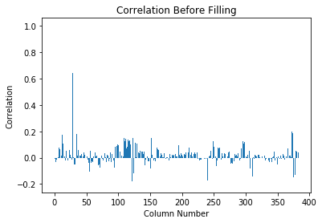

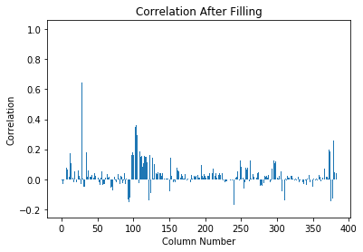

```python
data_filtered_corr_matrix_fil = data_filtered.corr()
drawCorrelationChart("Gender",data_filtered_corr_matrix, "Correlation Before Filling")
plt.figure()
drawCorrelationChart("Gender",data_filtered_corr_matrix_fil, "Correlation After Filling")
```

### 8.5. Post filling visualzation of missing values

No value in the dat left unfilled

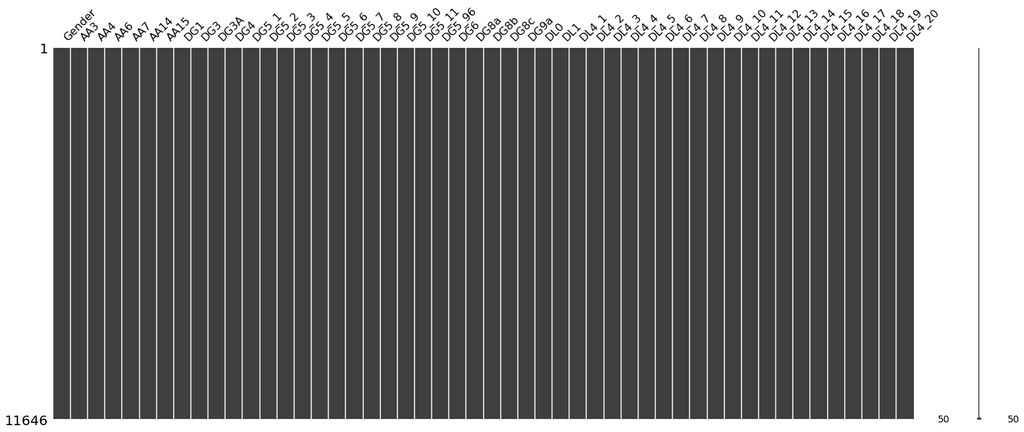

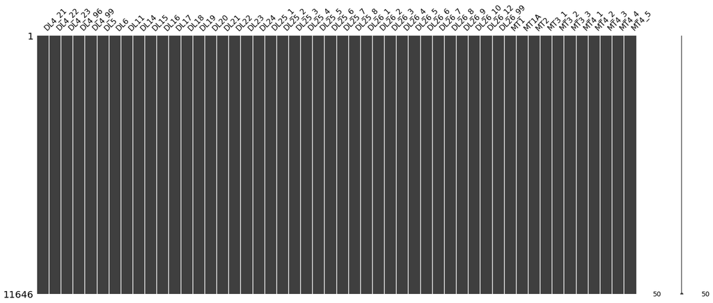

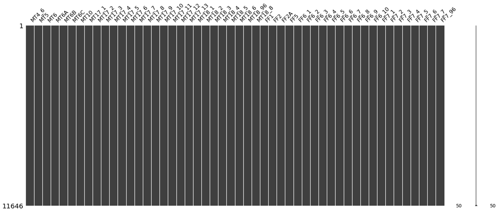

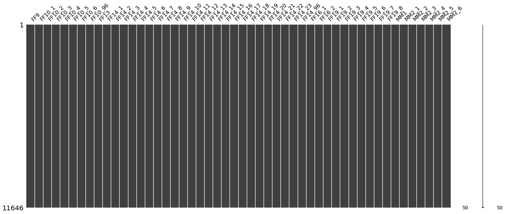

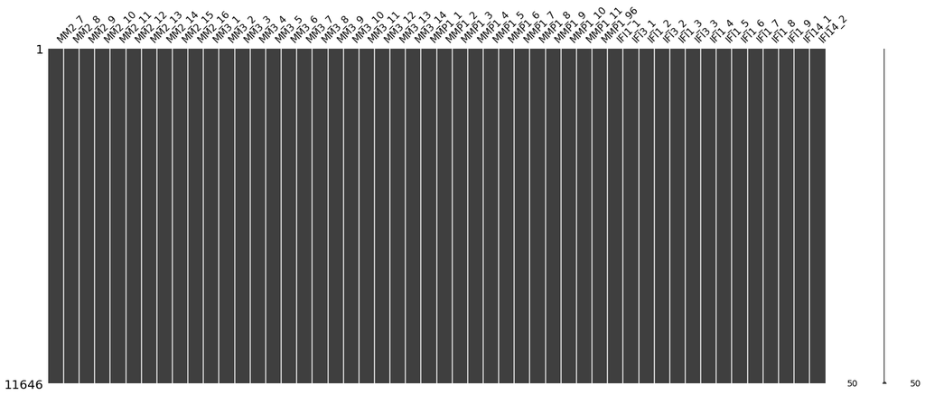

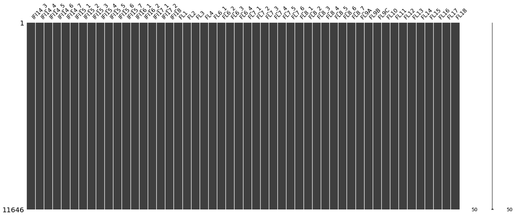

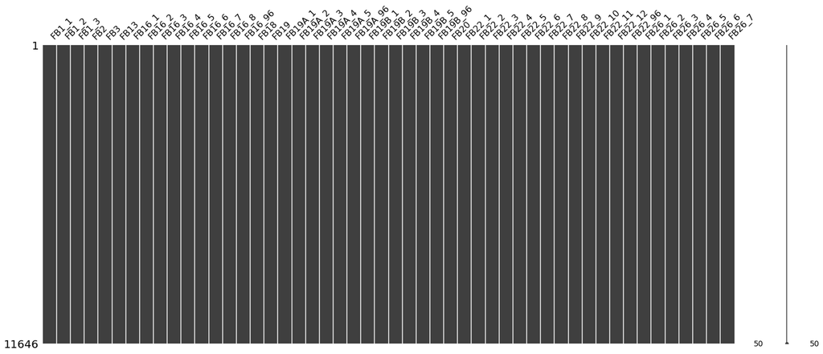

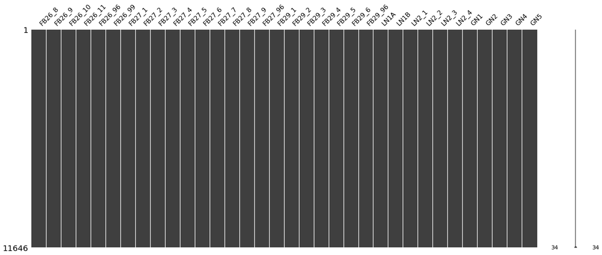

```python
cols = data_filtered.columns
cols_length = len(cols)
for index in range(0,cols_length,chunk_size):
    set = data_filtered[cols[index:index+chunk_size]]
    msno.matrix(set, inline=False)
```

### D. Storing the Cleaned/Preprocessed data in a sperate file

```python
data_filtered.to_csv (r'./data/filtered_data.csv', index = False, header=True)
```